# Final Exam Practice Questions - Part 2

**I know it’s tempting, but don’t click the solution tab until you are certain you have solved the question, or are utterly stumped by it.**

# Question 1.

### Use your R skills to examine the data sets **pairedDataA.csv** and **pairedDataB.csv** and determine which one actually contains paired data, and which one contains un-paired (independent) data.

**Click for Solution**

```r
library(tidyverse)

# The most logical way to go about this is to sort the data and look at it
dataA <- read_csv("pairedDataA.csv") |>
  arrange(Subject, Condition)

dataB <- read_csv("pairedDataB.csv") |>
  arrange(Subject, Condition)

dataA[1:4, ]
```

```
## # A tibble: 4 × 3
##   Subject Condition Score
##     <dbl> <chr>     <dbl>
## 1       1 G1        548.8
## 2       1 G2        257.3
## 3       2 G1        411.7
## 4       2 G2        352.6
```

```r
dataB[1:4, ]
```

```
## # A tibble: 4 × 3
##   Subject Condition Score
##     <dbl> <chr>     <dbl>
## 1       1 G1        499.9
## 2       2 G1        438.8
## 3       3 G1        555.9
## 4       4 G1        447.6
```

Since A has repeated subjects (i.e., one in each condition), A is paired.

# Question 2.

### Using the dataset you determined contained paired data, examine the assumption, of a classic paired t-test, that the data comes from a normality distributed population. Is the assumption satisfied?

**Click for Solution**

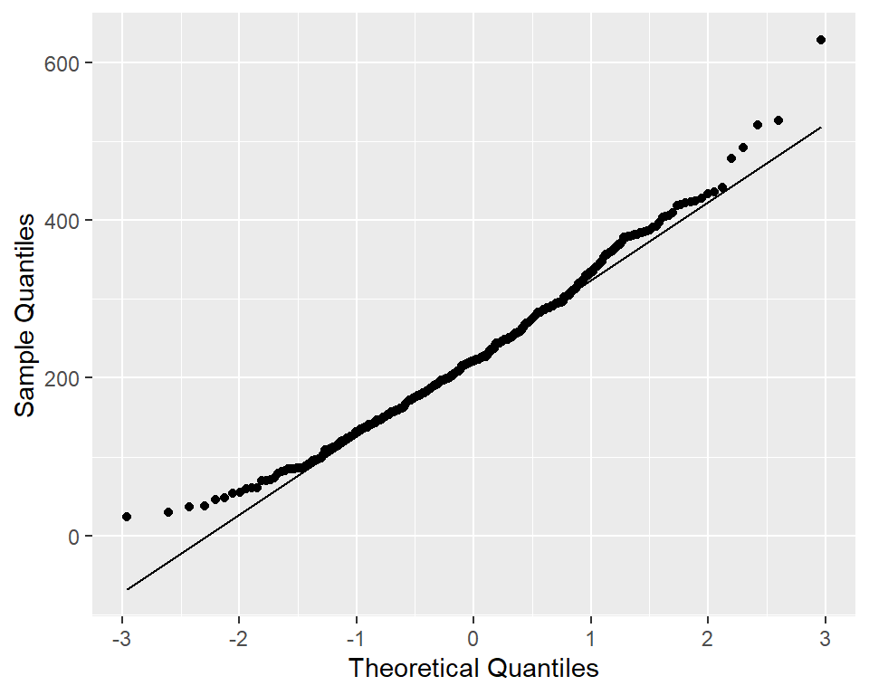

```r
# This is paired data, so we need to look at the difference scores
diff <- dataA$Score[dataA$Condition == "G1"] - dataA$Score[dataA$Condition == "G2"]

# Plot the differences on a qq plot
ggplot(mapping = aes(sample = diff)) +
  stat_qq() +
  stat_qq_line() +
  xlab("Theoretical Quantiles") +
  ylab("Sample Quantiles")
```

It’s not bad, but there appears to be a small arcing to the data’s line. If you can use a robust procedure, you probably should.

# Question 3.

### Using the previous question’s data, evaluate the hypothesis that $H_0: \mu_A - \mu_B > 0$ using a classic t-test. Report the test-statistic, degrees of freedom, 95% confidence interval. `t.test()` is not permitted.

**Click for Solution**

```r
# Get Difference scores
diff <-
  dataA$Score[dataA$Condition == "G1"] - dataA$Score[dataA$Condition == "G2"]

# Get Necessary Stats
n <- length(diff)
m_diff <- mean(diff)
s <- sd(diff)
se <- s / sqrt(n)
df <- n - 1

# Test
mu <- 0
t_stat <- (m_diff - mu) / se
p <- pt(t_stat, df = df)

# Confidence interval
alpha <- 0.05
t_crit <- abs(qt(alpha, df = df))
CI <- paste(
  "[",
  round(m_diff - Inf, 3), ", ",
  round(m_diff + t_crit * se, 3),
  "]",
  sep = ""
)
```

```
## T = 41.278
## df = 325
## p = 1
## CI = [-Inf, 239.208]
```

# Question 4.

### For the previous question, compute both a Cohen’s d and a Hedge’s g statistic. Which one should you use in this case? Use of `cohen.d()` is not permitted.

**Click for Solution**

```r
# Cohen's d
R <- cor(
  dataA$Score[dataA$Condition == "G1"],
  dataA$Score[dataA$Condition == "G2"]
)

s_rm <- s / sqrt(2 * (1 - R))

d <- m_diff / s_rm

# Hedge's g
g <- d * (1 - (3 / (4 * (n - 1) - 1)))
```

```
## d =  3.342
## g =  3.335
```

Since n > 50, Cohen’s d should be used.

# Question 5.

### Create a barplot of the means and the mean difference for the paired data you have been using. Use 95% confidence intervals for the errorbars.

**Click for Solution**

```r
# Create a tidy dataframe of the difference scores
Subject <- 1:length(n)
Condition <- rep("Diff", length(n))
Score <- diff
df_diff <- data.frame(Subject, Condition, Score)

# Bind to original data
dataA_diff <- rbind(dataA, df_diff)
```

```r
# Get group aggregates for plotting
plot_data <- dataA_diff |>
  group_by(Condition) |>
  summarise(
    n = length(Score),
    m = mean(Score),
    se = sd(Score) / sqrt(n),
    alpha = 0.05,
    df = n - 1,
    t_crit = abs(qt(alpha / 2, df = df)),
    moe = t_crit * se
  )

plot_data
```

```
## # A tibble: 3 × 8
##   Condition     n     m    se alpha    df t_crit    moe
##   <chr>     <int> <dbl> <dbl> <dbl> <dbl>  <dbl>  <dbl>
## 1 Diff        326 230.0 5.572  0.05   325  1.967 10.96
## 2 G1          326 503.0 4.257  0.05   325  1.967  8.375
## 3 G2          326 272.9 3.315  0.05   325  1.967  6.522
```

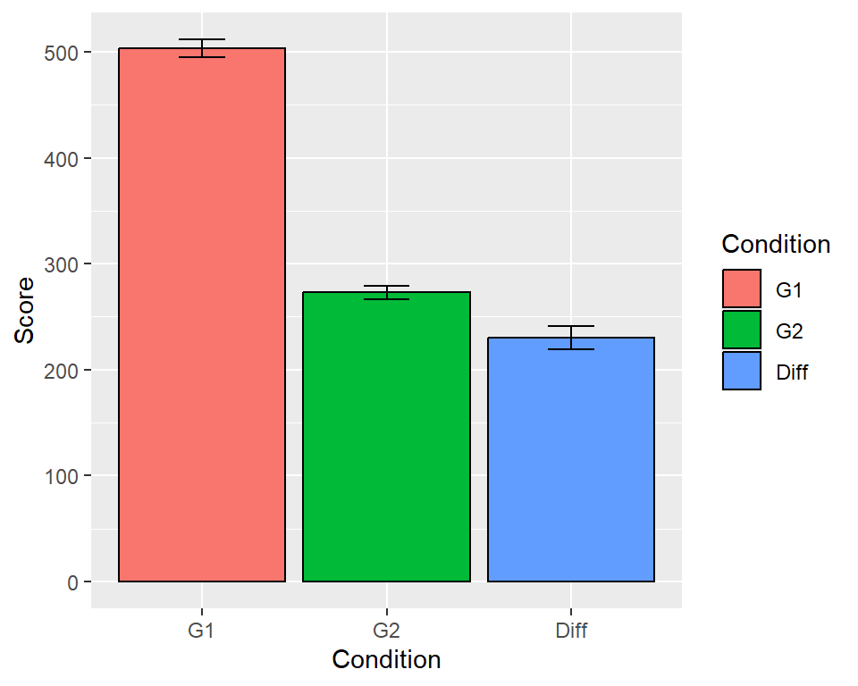

```r
# Reorder Factor levels
plot_data$Condition <- factor(plot_data$Condition,
  levels = c("G1", "G2", "Diff")
)

# Plot it
ggplot(plot_data, aes(x = Condition, y = m)) +
  geom_bar(
    stat = "identity",
    colour = "black",
    aes(fill = Condition)
  ) +
  geom_errorbar(
    aes(
      ymin = m - moe,
      ymax = m + moe
    ),
    width = 0.25
  ) +
  ylab("Score")
```

# Question 6.

### Using the paired data, repeat question 3, but examine the hypothesis $H_0: \mu_A - \mu_B > 250$.

**Click for Solution**

```r
# Nothing changes from Q3 except mu.
mu <- 250
t_stat <- (m_diff - mu)/se
p <- pt(t_stat, df = df)
```

```
## T =  -3.586
## df =  325
## p =  0.0001934624
## CI =  [-Inf, 239.208]
```

# Question 7.

### Using the paired data, repeat question 6, but use a trimmed t-test. Use 20% trimming.

**Click for Solution**

```r
library(WRS2)

# Basic Stats
G <- 0.20
m_diff <- mean(diff, tr = G)
s <- sqrt(winvar(diff, tr = G))

# Degrees of Freedom
h <- n - 2 * floor(G * n)
df <- h - 1

# Test
mu <- 250
t_stat <- ((1 - 2 * G) * (m_diff - mu)) / (s / sqrt(n))
p <- pt(t_stat, df = df)

# Confidence Interval
se <- s / ((1 - 2 * G) * sqrt(n))
alpha <- 0.05
t_crit <- abs(qt(alpha, df = df))
CI <- paste(
  "[",
  round(m_diff - Inf, 3), ", ",
  round(m_diff + t_crit * se, 3),
  "]",
  sep = ""
)
```

```
## T =  -4.556
## df =  195
## p =  4.582638e-06
## CI =  [-Inf, 232.953]
```

# Question 8.

### Create a barplot of the trimmed means and mean difference for the paired data you have been using. Use 95% confidence intervals for the errorbars.

**Click for Solution**

```r
# Get group aggregates for plotting using the dataframe with the difference scores.
plot_data <- dataA_diff |>
  group_by(Condition) |>
  summarise(
    n = length(Score),
    G = 0.20,
    m = mean(Score, tr = G),
    s = sqrt(winvar(Score, tr = G)),
    h = n - 2 * floor(G * n),
    df = h - 1,
    se = s / ((1 - 2 * G) * sqrt(n)),
    alpha = 0.05,
    t_crit = abs(qt(alpha / 2, df = df)),
    moe = t_crit * se
  )

plot_data
```

```
## # A tibble: 3 × 11
##   Condition     n     G     m     s     h    df    se alpha t_crit    moe
##   <chr>     <int> <dbl> <dbl> <dbl> <dbl> <dbl> <dbl> <dbl>  <dbl>  <dbl>
## 1 Diff        326   0.2 223.3 63.60   196   195 5.871  0.05  1.972 11.58
## 2 G1          326   0.2 493.2 54.64   196   195 5.044  0.05  1.972  9.948
## 3 G2          326   0.2 273.0 39.72   196   195 3.666  0.05  1.972  7.231
```

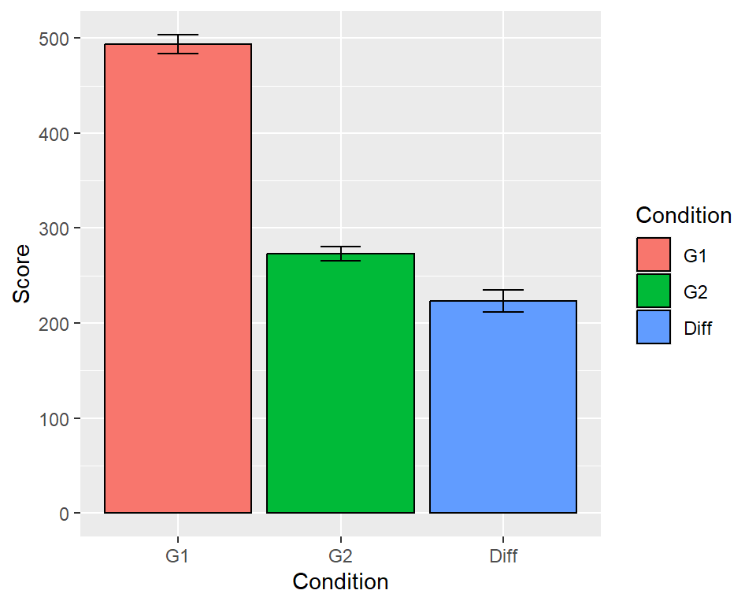

```r
# Reorder Factor levels
plot_data$Condition <- factor(plot_data$Condition,
  levels = c("G1", "G2", "Diff")
)

# Plot it
ggplot(plot_data, aes(x = Condition, y = m)) +
  geom_bar(
    stat = "identity",
    colour = "black",
    aes(fill = Condition)
  ) +
  geom_errorbar(
    aes(
      ymin = m - moe,
      ymax = m + moe
    ),
    width = 0.25
  ) +
  ylab("Score")
```

# Question 9.

### Without using `lm()`, fit a linear regression model (y~x) to the data in **regression.csv**. Write out the formula you obtain.

**Click for Solution**

```r
data <- read_csv("regression.csv")
b1 <- cor(data$x, data$y) * (sd(data$y) / sd(data$x))
b0 <- mean(data$y) - b1 * mean(data$x)
```

$\hat{Y} = 1324.958 + (-0.997) \cdot X$

# Question 10.

### Plot the regression data and the line you calculated for it. Do not use `geom_smooth()`.

**Click for Solution**

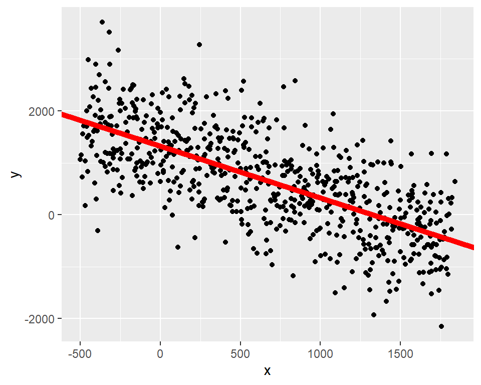

```r
ggplot(data, aes(x, y)) +
  geom_point() +
  geom_abline(intercept = b0, slope = b1, colour = "red", size = 2)
```

# Question 11.

### Examine the residuals of the model you made. Do they show heteroscedasticity and non-normality?

**Click for Solution**

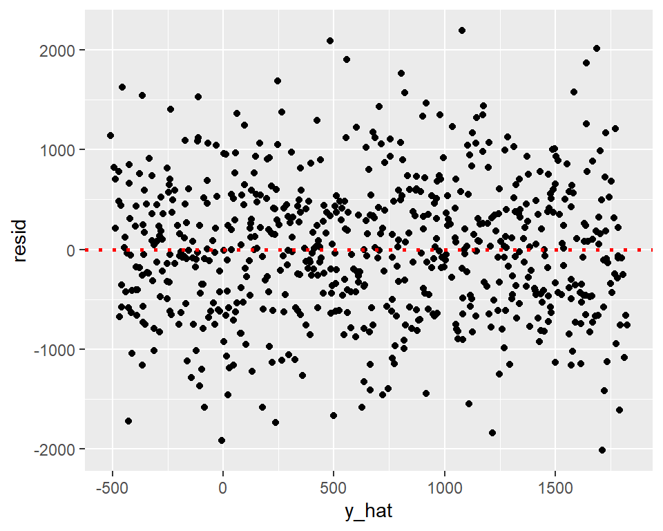

```r
# Get predicted values
data$y_hat <- b0 + b1 * data$x

# Get Residuals
data$resid <- data$y - data$y_hat

# Look at Residuals
ggplot(data, aes(x = y_hat, y = resid)) +
  geom_point() +
  geom_hline(yintercept = 0, linetype = 3, colour = "red", size = 1)
```

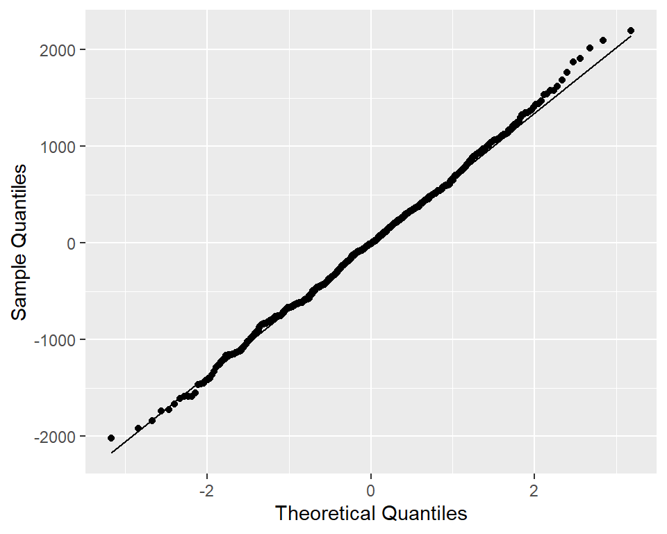

```r
# Look at QQ-plot of residuals
ggplot(data, aes(sample = resid)) +
  stat_qq() +
  stat_qq_line() +
  xlab("Theoretical Quantiles") +
  ylab("Sample Quantiles")
```

It does does not appear to violate either assumption.

# Question 12.

### Run a test to evaluate whether the slope is significantly different than 0. Report the, test statistic, degrees of freedom, p-value, and 95% confidence interval. Use of `lm()` and `confint()` is not permitted.

**Click for Solution**

```r
n <- nrow(data)

# Squared Standard Error of the Residuals
se_resid <- sum(data$resid^2) / (n - 2)

# Sum of squared deviation of X
SSx <- sum((data$x - mean(data$x))^2)

# Standard error of the slope
se_b1 <- sqrt(se_resid / SSx)

# Degrees of Freedom
df <- n - 1 - 1

# Test
B1 <- 0
t_stat <- (b1 - B1) / se_b1
p <- pt(t_stat, df = df) * 2

# Confidence Interval
alpha <- 0.05
t_crit <- abs(qt(alpha / 2, df = df))
CI <- paste(
  "[",
  round(b1 - t_crit * se_b1, 3), ", ",
  round(b1 + t_crit * se_b1, 3),
  "]",
  sep = ""
)
```

```
## T =  -24.769
## df =  664
## p =  1.981247e-96
## CI =  [-1.076, -0.918]
```

# Question 13.

### Examine whether the correlation between x and y for the **regression.csv** data is significantly different than 0. `cor.test()` is not permitted. Report the test statistic, degrees of freedom, and p-value.

**Click for Solution**

```r
rho <- 0
R <- cor(data$x, data$y)
se <- sqrt((1 - R^2) / (n - 2))

t_stat <- (R - rho) / se
df <- n - 2
p <- pt(abs(t_stat), df = df, lower.tail = FALSE) * 2
```

```
## T =  -24.769
## df =  664
## p =  1.981247e-96
```

# Question 14.

### Mireault (1990) studied students whose parent had died during their childhood. Among other things, she collected data on their current perceived sense of vulnerability to future loss (*PVLoss*), their level of social support (*SuppTotl*). This data can be found in **mireault.csv**

### Fit a linear regression model that predicts *DepressT* from the two variables mentioned above. Write out the model equation. You are allowed to use `lm()`.

**Click for Solution**

```r
data <- read_csv("mireault.csv")

mod_a <- lm(DepressT ~ PVLoss + SuppTotl, data = data)
```

$\hat{y} = 58.402 + (0.623) \cdot \text{PVLoss} + (-0.163) \cdot \text{SuppTotl}$

# Question 15.

### Another variable that Mireault (1990) recorded was the students’ gender. Create a second model that uses gender as a predictor. Conduct a test to determine if the model with gender included provides a significantly better fit than the model without it. Report the F-statistic, degrees of freedom, and p-value. Which model is preferred? You are not permitted to use `anova()`.

**Click for Solution**

```r
# Note that Mireault coded gender (a categorical variable) as 1 and 2.

#Factor Gender
data$Gender <- factor(data$Gender)
levels(data$Gender)
```

```
## [1] "1" "2"
```

```r
#Set Contrasts
G1_vs_G2 <- c(1, 0)
contrasts(data$Gender) <- G1_vs_G2

#New Model
mod_b <- lm(DepressT ~ PVLoss + SuppTotl + Gender, data = data)

# Note, a different way to do this in R would be to use the ifelse() function.
```

```r
#Store Summary Stats
mod_A_sum <- summary(mod_a)
mod_B_sum <- summary(mod_b)

#F-statistic
N <- nrow(data)
p_mod2 <- 3
p_diff <- 3 - 2
df1 <- p_diff
df2 <- N - p_mod2 - 1
R_sq_diff <- mod_B_sum$r.squared - mod_A_sum$r.squared

F_stat <- ((N - p_mod2 - 1) / p_diff) * (R_sq_diff / (1 - mod_B_sum$r.squared))

#p-value
p <- pf(F_stat, df1 = df1, df2 = df2, lower.tail = FALSE)
```

```
## [1] "F = 10.613, df1 = 1, df2 = 97, p = 0.002"
```

Including gender as a predictor significantly improves the model’s fit, making it the preferred model in this case.

# Question 16.

### Create plot of the residuals for the preferred model of the **mireault.csv** data. Does it violate the assumption of homoscedasticity?

**Click for Solution**

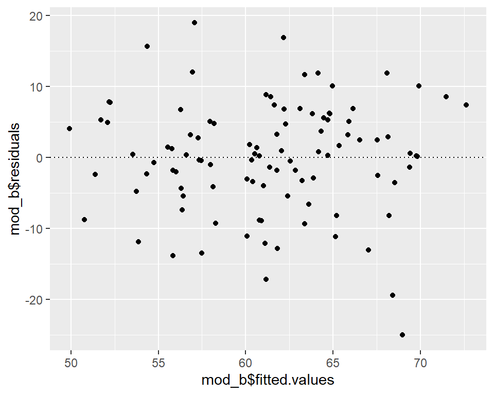

```r
ggplot(mapping = aes(x = mod_b$fitted.values, y = mod_b$residuals)) +
  geom_point() +
  geom_hline(yintercept = 0, linetype = 3)
```

No, the residuals appear evenly scattered across the x-axis.

# Question 17.

### Does the preferred model of the **mireault.csv** data violate the assumption of normally distributed residuals?

**Click for Solution**

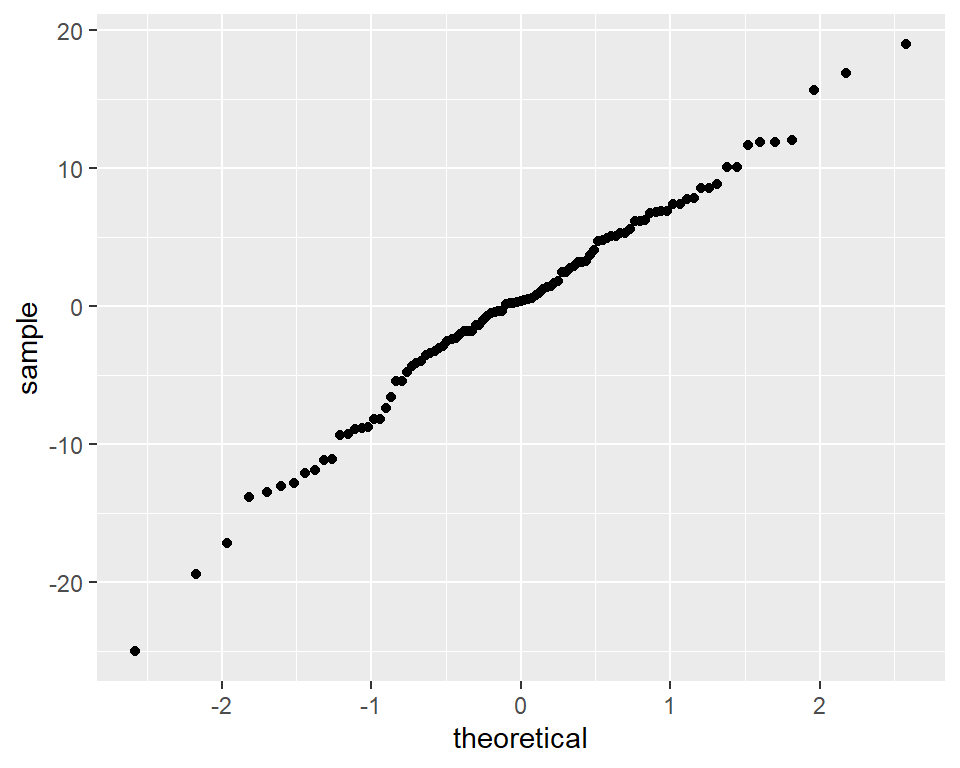

```r
ggplot(mapping = aes(sample = mod_b$residuals)) +
  stat_qq()
```

# Question 18.

### Is multicolinearity a problem for the preferred model of the **mireault.csv** data?

**Click for Solution**

```r
cor(data[, c("PVLoss", "SuppTotl")])
```

```
##              PVLoss   SuppTotl
## PVLoss   1.00000000 0.05703041
## SuppTotl 0.05703041 1.00000000
```

Given the very low correlation (or variance inflation factor, if you calculated that), multicolinearty does not seem to be an issue.

# Question 19.

### Assume you wanted to run a one-way ANOVA to see if there are any significant differences between your levels/groups If you have 7 levels, how big of a sample size would you need to detect a large effect?

**Click for Solution**

```r
library(pwr)
pwr.anova.test(k = 7, f = 0.40, sig.level = 0.05, power = 0.8)
```

```
##
##      Balanced one-way analysis of variance power calculation
##
##               k = 7
##               n = 13.09214
##               f = 0.4
##       sig.level = 0.05
##           power = 0.8
##
## NOTE: n is number in each group
```

# Question 20.

### The data **hemolymph.csv** shows the temperature (in degrees Celsius) and the concentration of a mineral in insect hemolymph (in millimoles per liter). Temperature is the independent variable and hemolymph the dependent variable. Plot a line chart of the means with 95% confidence intervals.

**Click for Solution**

```r
data <- read_csv("hemolymph.csv")

plot_data <- data |>
  group_by(degrees) |>
  summarise(
    n = length(hemolymph),
    GroupMean = mean(hemolymph),
    se = sd(hemolymph) / sqrt(n),
    df = n - 1,
    alpha = 0.05,
    t_crit = qt(alpha / 2, df = df, lower.tail = FALSE),
    moe = t_crit * se
  )

plot_data
```

```
## # A tibble: 7 × 8
##   degrees     n GroupMean     se    df alpha t_crit    moe
##     <dbl> <int>     <dbl>  <dbl> <dbl> <dbl>  <dbl>  <dbl>
## 1       3     8     3.474 0.4053     7  0.05  2.365 0.9583
## 2       5     8     5.190 0.2709     7  0.05  2.365 0.6407
## 3       8     8     6.433 0.4589     7  0.05  2.365 1.085
## 4      14     8     8.022 0.3949     7  0.05  2.365 0.9339
## 5      21     8     7.203 0.2091     7  0.05  2.365 0.4944
## 6      25     8     6.170 0.2291     7  0.05  2.365 0.5417
## 7      28     8     3.942 0.3387     7  0.05  2.365 0.8009
```

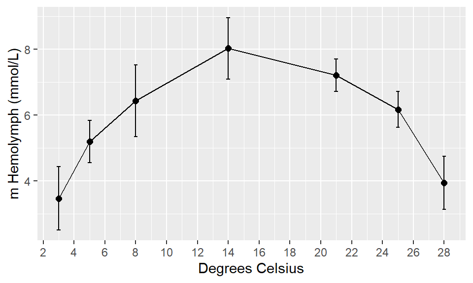

```r
ggplot(plot_data, aes(x = degrees, y = GroupMean)) +
  geom_line() +
  geom_point(colour = "black", size = 2) +
  geom_errorbar(
    aes(
      ymin = GroupMean - moe,
      ymax = GroupMean + moe
    ),
    width = 0.25
  ) +
  scale_x_continuous(breaks = seq(0, 30, 2)) +
  xlab("Degrees Celsius") +
  ylab("m Hemolymph (mmol/L)")
```

# Question 21.

### Conduct an omnibus one-way ANOVA F-test on the **hemolymph.csv** data. Report your F-stat, degrees of freedom, p-value, and $\omega^2$ effect size. Use of `lm()` or `aov()` is not permitted. Is the effect large?

**Click for Solution**

```r
# Grand m
grand_m <- mean(data$hemolymph)

# Total Sum of Squares
SST <- sum((data$hemolymph - grand_m)^2)

# Model Sum of Squares
SSM <- sum(plot_data$n * (plot_data$GroupMean - grand_m)^2)

# Residual Sum of Squares
SSR <- SST - SSM

# Degrees of Freedom
df_t <- nrow(data) - 1
df_m <- 7 - 1
df_r <- df_t - df_m

# m Squares
MSm <- SSM / df_m
MSr <- SSR / df_r

# F-Ratio
F_stat <- MSm / MSr

# p-value
p <- pf(F_stat, df1 = df_m, df2 = df_r, lower.tail = FALSE)

# Effect Size
omega_sq <- (SSM - df_m * MSr) / (SSM + SSR + MSr)
```

```
## [1] "F = 23.857, df1 = 6, df2 = 49, p = 0, w^2 = 0.71"
```

Yes, the effect size is very large.

# Question 22.

### Given the effect size obtained for the **hemolymph.csv** data, is the study underpowered? What is Cohen’s $f$ statsitic for the **hemolymph.csv** data?

- Note: the function `pwr.anova.test()` can’t handle a Cohen’s $f$ larger than 1.4.

**Click for Solution**

```r
#Cohen's F
R_sq = SSM / SST

cohen_f = sqrt(R_sq / (1 - R_sq))

pwr.anova.test(k = 7, f = 1.4, sig.level = 0.05, power = 0.8)
```

```
##
##      Balanced one-way analysis of variance power calculation
##
##               k = 7
##               n = 2.093126
##               f = 1.4
##       sig.level = 0.05
##           power = 0.8
##
## NOTE: n is number in each group
```

```
## Cohen's f = 1.709
```

Assuming an effect size of approx. 1.709 is actually occurring in the population, the study was not even remotely under powered.

- Note that you can use the function `pwr.anova.test()` to determine how much (post hoc) power the study had given the effect size it obtained by removing the `power =` argument and inputting the group sample size as `n =`. E.g., `pwr.anova.test(n = 8, k = 7, f = 1.4, sig.level = 0.05)`
- Also note that obtaining a large **post-hoc** power level does NOT mean your study has adequate power. A significant effect will always show high levels of power and you are more likely to get a significant result erroneously if your study lacks adequate power. Thus, significance and **post-hoc** power are confounded and you always need to consider power **prior** to running the study (i.e., power needs to be considered *a priori*).

# Question 23.

### What type of measurement scale is the predictor *degrees* for the **hemolymph.csv** data?

**Click for Solution**

Interval.

# Question 24.

### Conduct a trend analysis on the **hemolymph.csv** data. State which trend types are significant. What type of trend (as though it isn’t obvious) best describes the data?

**Click for Solution**

```r
# Factor Predictor
data$degrees <- factor(data$degrees)

# Set Contrasts
contrasts(data$degrees) <- contr.poly(levels(data$degrees))

# Fit Model to Test
summary(lm(hemolymph ~ degrees, data = data))
```

```
##
## Call:
## lm(formula = hemolymph ~ degrees, data = data)
##
## Residuals:
##      Min       1Q   Median       3Q      Max
## -1.90211 -0.68998  0.01345  0.61387  2.21515
##
## Coefficients:
##             Estimate Std. Error t value Pr(>|t|)
## (Intercept)  5.77627    0.12898  44.784  < 2e-16 ***
## degrees.L    0.78134    0.34125   2.290   0.0264 *
## degrees.Q   -3.91820    0.34125 -11.482 1.69e-15 ***
## degrees.C   -0.52377    0.34125  -1.535   0.1313
## degrees^4    0.36219    0.34125   1.061   0.2937
## degrees^5    0.04325    0.34125   0.127   0.8997
## degrees^6   -0.54726    0.34125  -1.604   0.1152
## ---
## Signif. codes:  0 '***' 0.001 '**' 0.01 '*' 0.05 '.' 0.1 ' ' 1
##
## Residual standard error: 0.9652 on 49 degrees of freedom
## Multiple R-squared:  0.745,  Adjusted R-squared:  0.7138
## F-statistic: 23.86 on 6 and 49 DF,  p-value: 5.568e-13
```

Linear and quadratic are significant, but given the shape of the data, quadratic is clearly the correct choice.

# Question 25.

### Fit the best type of trend line to the **hemolymph.csv** data and report the formula.

**Click for Solution**

```r
# Unfactor
data$degrees <- as.numeric(as.character(data$degrees))

# Create the squared predictor we need for the quadratic equation
data$degrees2 <- data$degrees^2

# Fit the Model
hemoMod <- lm(hemolymph ~ degrees + degrees2, data = data)
```

$\hat{y} = (1.297) + (0.865) \cdot x + (-0.027) \cdot x^2$

# Question 26.

### Plot the trend line from the previous question onto the raw data points.

**Click for Solution**

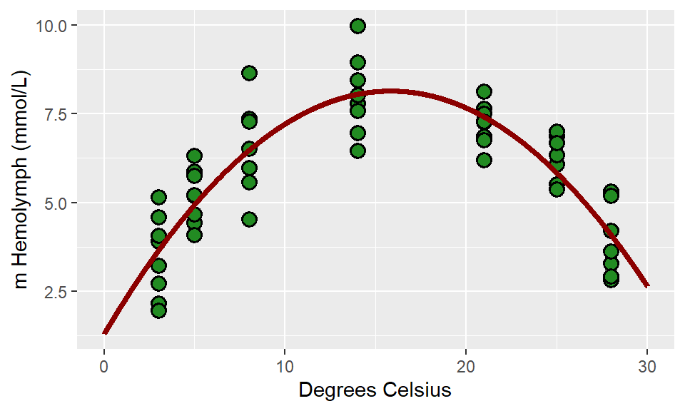

```r
# Get predicted values
x <- seq(0, 30, by = 0.01)

y <- hemoMod$coefficients[1] +
  hemoMod$coefficients[2] * x +
  hemoMod$coefficients[3] * x^2

modPreds <- data.frame(x, y)

# Plot them
ggplot(data, aes(x = degrees, y = hemolymph)) +
  geom_point(
    size = 3, shape = 21,
    fill = "forestgreen",
    colour = "black",
    stroke = 1
  ) +
  geom_line(
    data = modPreds, aes(x = x, y = y),
    colour = "red4", linewidth = 1.25
  ) +
  # scale_x_continuous(breaks = seq(0, 30, 2)) +
  xlab("Degrees Celsius") +
  ylab("m Hemolymph (mmol/L)")
```

# Question 27.

### Conduct Welch t-tests to see if there are significant pairwise differences between 3, 14, and 28 degrees. Which differences are signifcant according to a Holm-Bonferroni and Benjamini-Hochberg correction? Use of `p.adjust()` is prohibited.

**Click for Solution**

```r
# Subset groups
t3v14 <- filter(data, degrees == 3 | degrees == 14)
t3v28 <- filter(data, degrees == 3 | degrees == 28)
t14v28 <- filter(data, degrees == 14 | degrees == 28)

# Run the tests.
testA <- t.test(hemolymph ~ degrees, data = t3v14)
testB <- t.test(hemolymph ~ degrees, data = t3v28)
testC <- t.test(hemolymph ~ degrees, data = t14v28)

# Get the p-values and store in dataframe for convenience
Test <- c("A", "B", "C")
p <- c(testA$p.value, testB$p.value, testC$p.value)
df <- data.frame(Test, p)
```

```r
# Holm-Bonferroni---

# Sort dataframe from small to large
df_HB <- df[order(df$p), ]

# Assign Descending Index
df_HB$Index <- 3:1

# Get respective alpha levels
alpha <- 0.05
df_HB$alphaPrime <- alpha / df_HB$Index

# See which values are Significant
# (go from top down and stop when a comparison is no longer significant.)
df_HB$sig <- df_HB$p < df_HB$alphaPrime
df_HB
```

```
##   Test            p Index alphaPrime   sig
## 1    A 1.306886e-06     3 0.01666667  TRUE
## 3    C 2.006764e-06     2 0.02500000  TRUE
## 2    B 3.912616e-01     1 0.05000000 FALSE
```

```r
# Benjamini-Hochberg---

# Sort dataframe from small to large
df_BH <- df[order(df$p), ]

# Assign Ascending Index
df_BH$Index <- 1:3

# Get respective alpha levels
alpha <- 0.05
k <- 3
df_BH$alphaPrime <- (df_BH$Index / 3) * alpha

# See which values are Significant
# (go from bottom up and stop when a comparison is significant.)
df_BH$sig <- df_BH$p < df_BH$alphaPrime
df_BH
```

```
##   Test            p Index alphaPrime   sig
## 1    A 1.306886e-06     1 0.01666667  TRUE
## 3    C 2.006764e-06     2 0.03333333  TRUE
## 2    B 3.912616e-01     3 0.05000000 FALSE
```

Both the Holm-Bonferroni and Benjamini-Hochberg find a significant differences between 3 v 14 and 14 v 28, but not 3 vs 28.

# Question 28.

### A researcher is interested in whether the effects of cannabis vary with prior usage of the drug. An experiment is conducted in which 12 moderate users, 12 light users, and 12 students who had no prior use of cannabis are randomly sampled from a college population. Within each usage level, half of the subjects are randomly assigned to a placebo condition and the other half to an experimental condition. In the placebo condition, each subject smokes two regular cigarettes that taste and smell like cannabis cigarettes. In the experimental condition, each subject smokes two cannabis cigarettes. Immediately after finishing their cigarettes, each subject is given a reaction time test. The scores (in milliseconds) were recorded. The data for this experiment is found in **cannabis.csv.**

### Plot the means and 95% confidence intervals of the data. Does it look like there is an interaction?

**Click for Solution**

```r
data <- read_csv("cannabis.csv")

plot_data <- data |>
  group_by(Usage, Condition) |>
  summarise(
    n = length(RT),
    m = mean(RT),
    se = sd(RT) / sqrt(n),
    alpha = 0.05,
    df = n - 1,
    t_crit = abs(qt(alpha / 2, df = df)),
    moe = t_crit * se
  )

plot_data
```

```
## # A tibble: 6 × 9
## # Groups:   Usage [3]
##   Usage    Condition     n     m    se alpha    df t_crit   moe
##   <chr>    <chr>     <int> <dbl> <dbl> <dbl> <dbl>  <dbl> <dbl>
## 1 Light    Cannabis      6 762   26.38  0.05     5  2.571 67.82
## 2 Light    Placebo       6 704.8 28.52  0.05     5  2.571 73.31
## 3 Moderate Cannabis      6 732.3 26.68  0.05     5  2.571 68.58
## 4 Moderate Placebo       6 696   28.93  0.05     5  2.571 74.38
## 5 None     Cannabis      6 879.2 22.44  0.05     5  2.571 57.68
## 6 None     Placebo       6 701.7 28.01  0.05     5  2.571 72.01
```

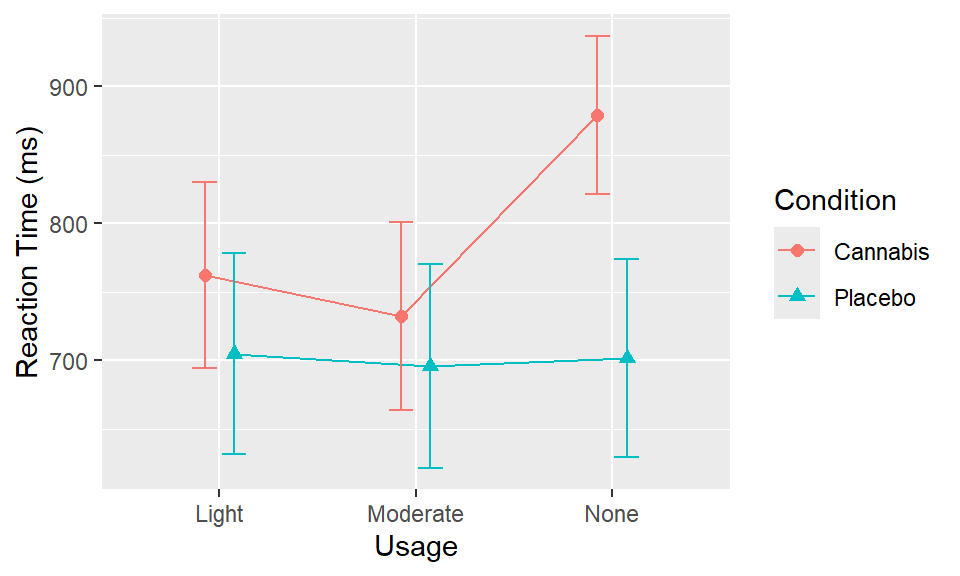

```r
ggplot(plot_data, aes(
  x = Usage, y = m,
  group = Condition, colour = Condition, shape = Condition
)) +
  geom_line(position = position_dodge(width = 0.3)) +
  geom_point(size = 2, position = position_dodge(width = 0.3)) +
  geom_errorbar(
    aes(ymin = m - moe, ymax = m + moe),
    width = 0.25,
    position = position_dodge(width = 0.3)
  ) +
  xlab("Usage") +
  ylab("Reaction Time (ms)")
```

The lines are not parallel, so there is likely an interaction between Condition and Usage.

# Question 29.

### Using the **cannabis.csv.** data, test for main effects and an interaction. Report the F ratios, their degrees of freedom, p-value and an $\omega^2$ measure of effect size. You are not permitted to use `lm()` or `aov()`.

**Click for Solution**

```r
grand_m <- mean(data$RT)
N <- nrow(data)

# Total Sum of Squares
SST <- sum((data$RT - grand_m)^2)
```

```r
# Model Sum of Squares
sum_stat <- data |>
  group_by(Usage, Condition) |>
  summarise(
    n = length(RT),
    m = mean(RT)
  )

SSM <- sum(sum_stat$n * (sum_stat$m - grand_m)^2)
```

```r
# Main Effect of Usage: SSA
sum_stat_A <- data |>
  group_by(Usage) |>
  summarise(
    n = length(RT),
    m = mean(RT)
  )

SSA <- sum(sum_stat_A$n * (sum_stat_A$m - grand_m)^2)

# Degrees of Freedom A
dfA <- nrow(sum_stat_A) - 1
```

```r
# Main Effect of Condition: SSB
sum_stat_B <- data |>
  group_by(Condition) |>
  summarise(
    n = length(RT),
    m = mean(RT)
  )

SSB <- sum(sum_stat_B$n * (sum_stat_B$m - grand_m)^2)

# Degrees of Freedom B
dfB <- nrow(sum_stat_B) - 1
```

```r
# Interaction between A and B (SSI)
SSI <- SSM - SSA - SSB

# Degrees of Freedom I
dfI <- dfA * dfB
```

```r
# Residual Sum of Squares (SSR)
SSR <- SST - SSM

# Degrees of Freedom R
A <- length(unique(data$Usage))
B <- length(unique(data$Condition))
dfR <- (N - 1) - (A - 1) - (B - 1) - (A - 1) * (B - 1)
```

```r
# Mean Squares
MSA <- SSA / dfA
MSB <- SSB / dfB
MSI <- SSI / dfI
MSR <- SSR / dfR
```

```r
# F-Ratios
FA <- MSA / MSR
FB <- MSB / MSR
FI <- MSI / MSR
```

```r
# P-Values
pA <- pf(FA, df1 = dfA, df = dfR, lower.tail = FALSE)
pB <- pf(FB, df1 = dfB, df = dfR, lower.tail = FALSE)
pI <- pf(FI, df1 = dfI, df = dfR, lower.tail = FALSE)
```

```r
# Effect Sizes
omegasqA <- (SSA - (A - 1) * (MSR)) / (SST + MSR)
omegasqB <- (SSB - (B - 1) * (MSR)) / (SST + MSR)
omegasqI <- (SSI - (A - 1) * (B - 1) * (MSR)) / (SST + MSR)
```

```
## Main Effect of Usage:
##     F = 4.341, df1 = 2, df2 = 30, p = 0.02209379, omega^2 = 0.103
##
## Main Effect of Condition:
##     F = 16.896, df1 = 1, df2 = 30, p = 0.0002815786, omega^2 = 0.246
##
## Interaction Effect:
##     F = 4.008, df1 = 2, df2 = 30, p = 0.02866237, omega^2 = 0.093
```

# Question 30.

### Given the previous question, describe what the main effects and interactions mean for the cannabis study in plain English and whether they were significant.

**Click for Solution**

- There was a significant main effect of *usage*, meaning that, when *Condition* is ignored, there was at least one significant difference amoung the levels.
- There was a significant main effect of *Condition*, meaning that, when *Usage* is ignored, there is a significant difference between the *Placebo* and *Cannabis* levels.
- There was a significant interaction between *Usage* and *Condition*, meaining that the effect of *Usage* was significantly different across the *Placebo* and *Cannabis* conditions.

# Question 31.

### Recalcualte the two-way ANOVA from the previous question using the `lm()` function and set planned comparisons to test whether non-users of cannabis differed from users of cannabis, in both the placebo and experimental conditions.

**Click for Solution**

```r
# Usage Comparisons
data$Usage <- factor(data$Usage)
levels(data$Usage) # Light, Moderate, None
```

```
## [1] "Light"    "Moderate" "None"
```

```r
# Contrast 1:
LM_v_N <- c(1, 1, -2)

# Contrast 2:
L_v_M <- c(1, -1, 0)

# Set Contrasts
contrasts(data$Usage) <- cbind(LM_v_N, L_v_M)
```

```r
# Condition Comparisons
data$Condition <- factor(data$Condition)
levels(data$Condition) # "Cannabis" "Placebo"
```

```
## [1] "Cannabis" "Placebo"
```

```r
# Contrast 1:
C_v_P <- c(1, -1)

# Set Contrasts
contrasts(data$Condition) <- cbind(C_v_P)
```

```r
# The Model
model <- lm(RT ~ Usage + Condition + Usage * Condition, data = data)
summary(model)
```

```
##
## Call:
## lm(formula = RT ~ Usage + Condition + Usage * Condition, data = data)
##
## Residuals:
##     Min      1Q  Median      3Q     Max
## -97.333 -50.417   2.833  49.833  95.167
##
## Coefficients:
##                            Estimate Std. Error t value Pr(>|t|)
## (Intercept)                 746.000     10.988  67.892  < 2e-16 ***
## UsageLM_v_N                 -22.208      7.770  -2.858 0.007672 **
## UsageL_v_M                    9.625     13.458   0.715 0.480008
## ConditionC_v_P               45.167     10.988   4.111 0.000282 ***
## UsageLM_v_N:ConditionC_v_P  -21.792      7.770  -2.805 0.008752 **
## UsageL_v_M:ConditionC_v_P     5.208     13.458   0.387 0.701474
## ---
## Signif. codes:  0 '***' 0.001 '**' 0.01 '*' 0.05 '.' 0.1 ' ' 1
##
## Residual standard error: 65.93 on 30 degrees of freedom
## Multiple R-squared:  0.5283, Adjusted R-squared:  0.4496
## F-statistic: 6.719 on 5 and 30 DF,  p-value: 0.0002619
```

# Question 32.

### In plain English, interpret each coefficent from the previous question’s model.

**Click for Solution**

**UsageL_v_M:** There is no significant difference between *Light* and *Moderate* users’ reaction time (when *Condition* is ignored).

**ConditionC_v_P:** There was a significant difference in reaction time between the *Placebo* and *cannabis* conditions (*cannabis* was slower).

- Note: because there are only two levels in the factor *Condition*, this result is just a restatement of the *Main Effect of Condition*.

**UsageLM_v_N:ConditionC_v_P:** The significant difference seen between the users and the non-users depended on which *Condition* was received.

**UsageL_v_M:ConditionC_v_P:** *Condition* has no impact on the reaction times seen between the *Light* and *Moderate* users.

# Question 33.

### Conduct a simple effects analysis that tests the difference between the Placebo and cannabis conditions at each level of Usage. Which comparisons are significant?

**Click for Solution**

```r
# Create a new column with all the level combinations
data$All_levels <- paste(data$Usage, data$Condition, sep = "_")

# Factor the new column
data$All_levels <- factor(data$All_levels)
levels(data$All_levels)
```

```
## [1] "Light_Cannabis"    "Light_Placebo"     "Moderate_Cannabis"
## [4] "Moderate_Placebo"  "None_Cannabis"     "None_Placebo"
```

```r
# LM, KP, MM, MP, NM, NP
cont1 <- c(1, 1, 1, 1, -2, -2)
cont2 <- c(1, 1, -1, -1, 0, 0)
cont3 <- c(1, -1, 0, 0, 0, 0)
cont4 <- c(0, 0, 1, -1, 0, 0)
cont5 <- c(0, 0, 0, 0, 1, -1)

grid <- cbind(cont1, cont2, cont3, cont4, cont5)


# Check if each contrast sums to zero
apply(grid, MARGIN = 2, FUN = sum)
```

```
## cont1 cont2 cont3 cont4 cont5
##     0     0     0     0     0
```

```r
# Check if contrasts are orthogonal
sum(apply(grid, MARGIN = 1, FUN = prod))
```

```
## [1] 0
```

```r
# Set Contrasts
contrasts(data$All_levels) <- grid
contrasts(data$All_levels)
```

```
##                   cont1 cont2 cont3 cont4 cont5
## Light_Cannabis        1     1     1     0     0
## Light_Placebo         1     1    -1     0     0
## Moderate_Cannabis     1    -1     0     1     0
## Moderate_Placebo      1    -1     0    -1     0
## None_Cannabis        -2     0     0     0     1
## None_Placebo         -2     0     0     0    -1
```

```r
simple <- lm(RT ~ All_levels, data = data)
simple_sum <- summary(simple)
simple_sum
```

```
##
## Call:
## lm(formula = RT ~ All_levels, data = data)
##
## Residuals:
##     Min      1Q  Median      3Q     Max
## -97.333 -50.417   2.833  49.833  95.167
##
## Coefficients:
##                 Estimate Std. Error t value Pr(>|t|)
## (Intercept)      746.000     10.988  67.892  < 2e-16 ***
## All_levelscont1  -22.208      7.770  -2.858  0.00767 **
## All_levelscont2    9.625     13.458   0.715  0.48001
## All_levelscont3   28.583     19.032   1.502  0.14359
## All_levelscont4   18.167     19.032   0.955  0.34744
## All_levelscont5   88.750     19.032   4.663 6.02e-05 ***
## ---
## Signif. codes:  0 '***' 0.001 '**' 0.01 '*' 0.05 '.' 0.1 ' ' 1
##
## Residual standard error: 65.93 on 30 degrees of freedom
## Multiple R-squared:  0.5283, Adjusted R-squared:  0.4496
## F-statistic: 6.719 on 5 and 30 DF,  p-value: 0.0002619
```

Only the non non-users showed a significant difference between the two conditions.

# Question 34.

### For the significant effects found in the previous question, compute an effect size in terms of Cohen’s d or Hedge’s g (whichever is more appropriate).

**Click for Solution**

```r
# Subset the section of data I need
NP <- subset(data, All_levels == "None_Placebo")
NM <- subset(data, All_levels == "None_Cannabis")

# Pooled Standard deviation
n_NP <- nrow(NP)
n_NM <- nrow(NM)

sp <- sqrt(
  ((n_NP - 1) * var(NP$RT) + (n_NM - 1) * var(NM$RT)) /
    (n_NP + n_NM - 2)
)

# Cohen's d
d <- (mean(NP$RT) - mean(NM$RT)) / sp

# Hedge's g
g <- d * (1 - (3 / (4 * (n_NP + n_NM) - 9)))
```

```
## g =  -2.636
```

# Question 35.

### Zar (1999) presented a dataset that depectied the classification of 250 plants into one of four categories on the basis of seed type (yellow smooth, yellow wrinkled, green smooth, and green wrinkled). Zar used these data to test the null hypothesis that the sample came from a population that had a 9:3:3:1 ratio of these seed types. Test that hypothesis without using `chisq.test()`. The following code will generate the data:

```r
count <- c(152, 39, 53, 6)
type <- c("YellowSmooth", "YellowWrinkled", "GreenSmooth", "GreenWrinkled")
seeds <- data.frame(type, count)
seeds
```

### Report the test-statistic, degrees of freedom, and p-value. Does the sample likey to come from a population with the hypothesized ratio?

- Zar, G. H. (1999). *Biostatistical methods*. Prentice-Hall, New Jersey.

**Click for Solution**

```r
# Calculate the expected frequencies:
# The hypothesized ratio of seeds given allows us to calculate the probability of each (expected) seed type.
# We can use those probabilities to determine how many seeds are expected.

# Create a column of probabilities
seeds$probs <- c(9 / 16, 3 / 16, 3 / 16, 1 / 16)

# Expected Frequencies
totalSeeds <- sum(seeds$count)
seeds$expect <- seeds$probs * totalSeeds

# Now run the test:
chiSq <- sum(((seeds$count - seeds$expect)^2) / seeds$expect)

# Degrees of freedom
df <- 4 - 1

# p-value
p <- pchisq(chiSq, df = df, lower.tail = FALSE)
```

```
## Chi-Sq = 8.972, df = 3, p = 0.0296595
```

Since p < 0.05, it seems unlikely that the sample came from a population with a 9:3:3:1 ratio.

# Question 36.

### In order to investigate the mortality of Coolibah (*Eucalyptus coolibah*) trees across Riparian dunes, Roberts (1993) recorded the postion (top, middle, and bottom) of a quadrat along a floodplain and whether it contained dead trees (with and without).

### Note: a “quadrat” is marked off square plot of land used in research. In this case, the classification of quadrats according to the presence/absence of dead Coolibah trees will be interpreted as a response variable and the position along the floodplane a predictor variable. The data can be found in **“roberts.csv”**.

- Roberts, J. (1993), Regeneration and growth of coolibah, *Eucalyptus coolabah* subsp. *arida*, a riparian tree, in the Cooper Creek region of South Australia. *Australian Journal of Ecology*, *(18)*, 345-350. https://doi.org/10.1111/j.1442-9993.1993.tb00461.x

### The datafile contains the raw data, create a contingency table using the information it contains.

- Hint: there is a stupidly easy way to do this in R that rhymes with “mable”.

**Click for Solution**

```r
treeData <- read_csv("roberts.csv")

treeTab <- table(treeData$POSITION, treeData$DEAD)
treeTab
```

```
##
##          With Without
##   Bottom   15      13
##   Middle    4       8
##   Top       0      17
```

# Question 37.

### Without using `chisq.test()`, conduct a $\chi^2$ test to evaluate whether the presense/absence of dead coolibah trees dependent on position. Report the test-statistic, degrees of freedom, and p-value.

**Click for Solution**

```r
# This will be simplest if we turn our table into a dataframe with two columns.  R has a convenient way of doing this:
trees <- as.data.frame.matrix(treeTab)
trees <- trees

# Add row names to the dataframe for a nice elegant dataframe; though, this is not strictly necessary.
row.names(trees) <- c("Bottom", "Middle", "Top")
trees
```

```
##        With Without
## Bottom   15      13
## Middle    4       8
## Top       0      17
```

```r
# Get Row, Column Totals, and Overall Total
row_total <- apply(trees, MARGIN = 1, FUN = sum)
col_total <- apply(trees, MARGIN = 2, FUN = sum)

# Get Total number of Trees
N <- sum(row_total)

# Get expected Frequencies
## You can do this the long way, or you can use matrix multiplication (i.e., see the last Homework solutions for an explanation).
expected <- row_total %*% t(col_total) / N
```

```r
# Calculate the test-statistic
chiSq <- sum(((trees - expected)^2) / expected)

# Degrees of Freedom
df <- (3 - 1) * (2 - 1)

# p-value
p <- pchisq(chiSq, df = df, lower.tail = FALSE)
```

```
## Chi-Sq = 13.66071, df = 2, p = 0.001080472
```

Since p < 0.05, and the null hypothesis are that the two variables are independent, it seems likely that the presense/absence of dead coolibah trees is dependent on position.

# Question 38.

### What are the odds of finding a dead tree in the middle position?

**Click for Solution**

```r
#(With | Middle)
with_mid <- 4 / 8
```

The odds of finding a dead tree, given that you are looking in the middle position of the quadrat, is 0.5 to 1.

# Question 39.

### What is the probability of finding a dead tree in the middle position?

**Click for Solution**

```r
#(With | Middle)
with_mid_pr <- 4 / (4 + 8)
```

The probability of finding a dead tree, given that you are looking in the middle position of the quadrat is 0.333. i.e., There is a 33.3% chance.

# Question 40.

### What are the odds of finding a dead tree in the top position?

**Click for Solution**

```r
#(With | Top)
withTop <- 0 / 17
```

- Note: One assumes that, in the real world, there probably isn’t a perfect guarantee. If having a guarantee bothers you or you end up with a 0 in the denominator, creating a reality destroying paradox, you can just add a really really small inconsequential value to your numerator and denominator, e.g., 0.000001.